# R Notebook for Titanic Kaggle data analysis XGboost

Vikram Mitra

# 1 Introduction

This is a [R Markdown](http://rmarkdown.rstudio.com) Notebook for analysis of the Titanic dataset.

## 1.1 Load libraries

[output not shown]

# 2 Read data and feature engineering

After reading the data into the R environment, I created a new variable called **Title**. Cleaned up **Ticket** column and removed any alpha-numeric data. Created Family and Family size variables. Here, as usual family fize was constructed as $SibSp$ + $Parch$ + $1$ (including the passenger themselves) Also created the Survived status column in the test data table before combining the two datasets.

```r
test_df<- fread(input = "input/test.csv")
test_df$Survived<- NA
train_df <- fread(input = "input/train.csv")

combined_data<- rbind(test_df,train_df[,colnames(test_df),with=FALSE])
combined_data$Title<- gsub("\\..*","",gsub(".*\\,","",combined_data$Name))
combined_data$Ticket<- gsub("[^[:alnum:] ]","",combined_data$Ticket)
combined_data$Ticket<- as.numeric(gsub("[^0-9\\.]","",combined_data$Ticket))

# Create a family size variable
combined_data$Fsize <- combined_data$SibSp + combined_data$Parch + 1
combined_data$Surname <- gsub("\\,.*","",combined_data$Name)
# Create a family variable
combined_data$Family <- paste(combined_data$Surname, combined_data$Fsize, sep='_')

# Changing the Cabin variable column - claning and creating an imaginary value for 'blank' information
combined_data[Cabin==""]$Cabin<- "Z"
combined_data[!is.na(Cabin)]$Cabin<- gsub("[[:digit:]]","",combined_data$Cabin)
```

# 3 Exploratory analysis and summary statistics

```r
summary(combined_data)
```

```
##   PassengerId       Pclass          Name               Sex
##  Min.   :   1   Min.   :1.000   Length:1309        Length:1309
##  1st Qu.: 328   1st Qu.:2.000   Class :character   Class :character
##  Median : 655   Median :3.000   Mode  :character   Mode  :character
##  Mean   : 655   Mean   :2.295
##  3rd Qu.: 982   3rd Qu.:3.000
##  Max.   :1309   Max.   :3.000
##
##       Age            SibSp            Parch           Ticket
##  Min.   : 0.17   Min.   :0.0000   Min.   :0.000   Min.   :       2
##  1st Qu.:21.00   1st Qu.:0.0000   1st Qu.:0.000   1st Qu.:   16966
##  Median :28.00   Median :0.0000   Median :0.000   Median :  113038
##  Mean   :29.88   Mean   :0.4989   Mean   :0.385   Mean   :  659943
##  3rd Qu.:39.00   3rd Qu.:1.0000   3rd Qu.:0.000   3rd Qu.:  347083
##  Max.   :80.00   Max.   :8.0000   Max.   :9.000   Max.   :23101294
##  NA's   :263                                      NA's   :4
##       Fare            Cabin             Embarked            Survived
##  Min.   :  0.000   Length:1309        Length:1309        Min.   :0.0000
##  1st Qu.:  7.896   Class :character   Class :character   1st Qu.:0.0000
##  Median : 14.454   Mode  :character   Mode  :character   Median :0.0000
##  Mean   : 33.295                                         Mean   :0.3838
##  3rd Qu.: 31.275                                         3rd Qu.:1.0000
##  Max.   :512.329                                         Max.   :1.0000
##  NA's   :1                                               NA's   :418
##     Title               Fsize          Surname             Family
##  Length:1309        Min.   : 1.000   Length:1309        Length:1309
##  Class :character   1st Qu.: 1.000   Class :character   Class :character
##  Mode  :character   Median : 1.000   Mode  :character   Mode  :character
##                     Mean   : 1.884
##                     3rd Qu.: 2.000
##                     Max.   :11.000
##
```

Summaring the data shows that variables **Age** , **Fare** and Ticket have missing data points. Missing data in these variables can be imputed from other variables. However before imputation lets check how the variables are correlated with each other.

# 4 Imputing missing data points

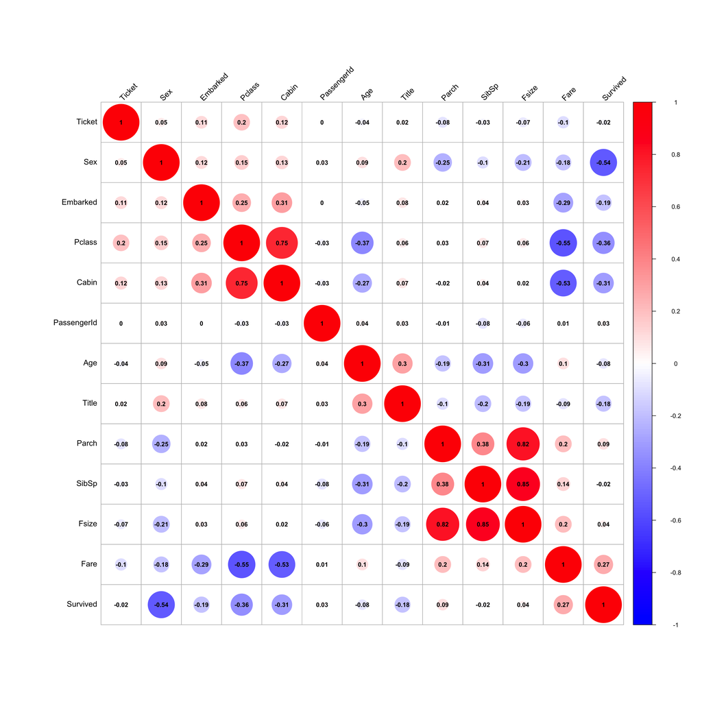

```r
# converting factor variables to discrete numeric variables
varibles_to_convert <- c('Sex','Title','Embarked','Cabin')
combined_data[,(varibles_to_convert):= lapply(.SD, FUN = function(x) as.numeric(as.factor(x))), .SDcols = varibles_to_convert]

colsTouse<- colnames(combined_data)
colsTouse<-colsTouse[!colsTouse %in% c("Name","Family","Surname")]

corr_matrix <- cor(combined_data[,.SD,.SDcols = colsTouse],use = "complete.obs")
corrplot(corr_matrix, type = "full",method = "circle",order = "hclust",
         tl.col = "black", tl.srt = 45,number.cex = 0.8,
         number.digits = 2,col=colorRampPalette(c("blue","white","red"))(200),
         addCoef.col="black")
```

```r
combined_data[is.na(Fare),"Fare"]<- mean(combined_data[Survived==1]$Fare)
```

```r
# Use variables for imputing Age [variables most correlated with Age]
combined_data_AgeCorr_vars <- c('Sex','Title','Fare','Age')
# Set a random seed
set.seed(129)

# Perform mice imputation, excluding certain less-than-useful variables
mice_mod <- mice(combined_data[,combined_data_AgeCorr_vars,with=FALSE], method='rf')
mice_output <- complete(mice_mod)

# Noe creating Age group as a new variable
combined_data_new<- combined_data
combined_data_new$Age<- mice_output$Age
combined_data_new[combined_data_new$Age <=18,"AgeGroup"] <- paste("Child")
combined_data_new[combined_data_new$Age >18,"AgeGroup"]<- paste("Adult")
```

Now plotting distributions - *First* - Age before and after Imputation

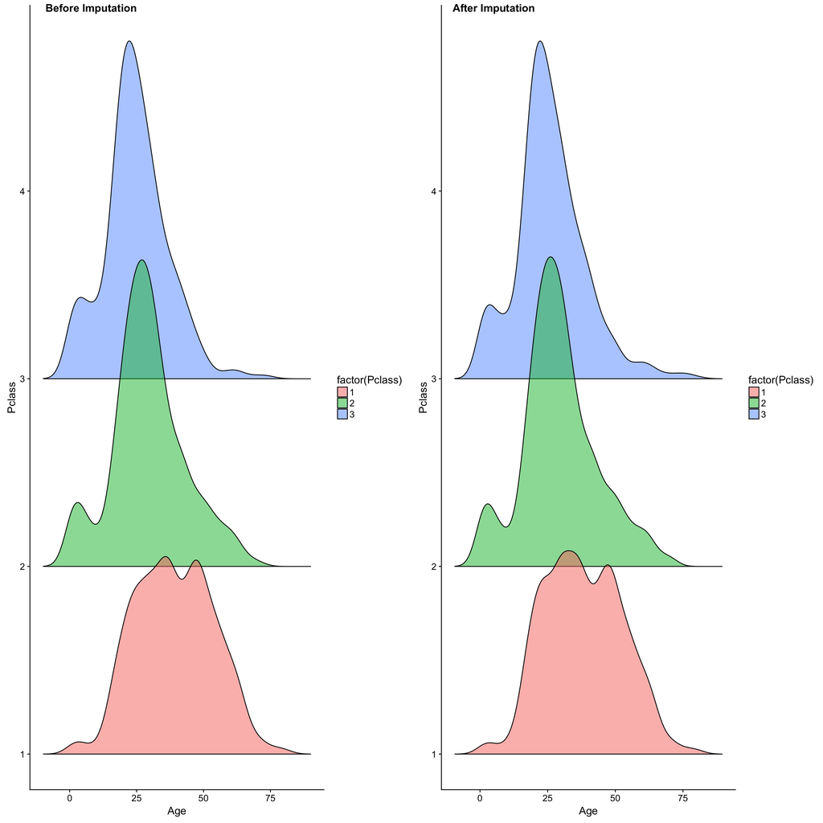

```r
p_before_imputation <- ggplot(combined_data, aes(x = Age, y= Pclass, group = Pclass,
                                                 fill=factor(Pclass))) + geom_density_ridges2(alpha=0.5)

p_after_imputation <- ggplot(combined_data_new, aes(x = Age, y= Pclass, group = Pclass,
                                                    fill=factor(Pclass))) + geom_density_ridges2(alpha=0.5)
plot_grid(p_before_imputation, p_after_imputation, nrow=1, labels=c('Before Imputation', 'After Imputation'))
```

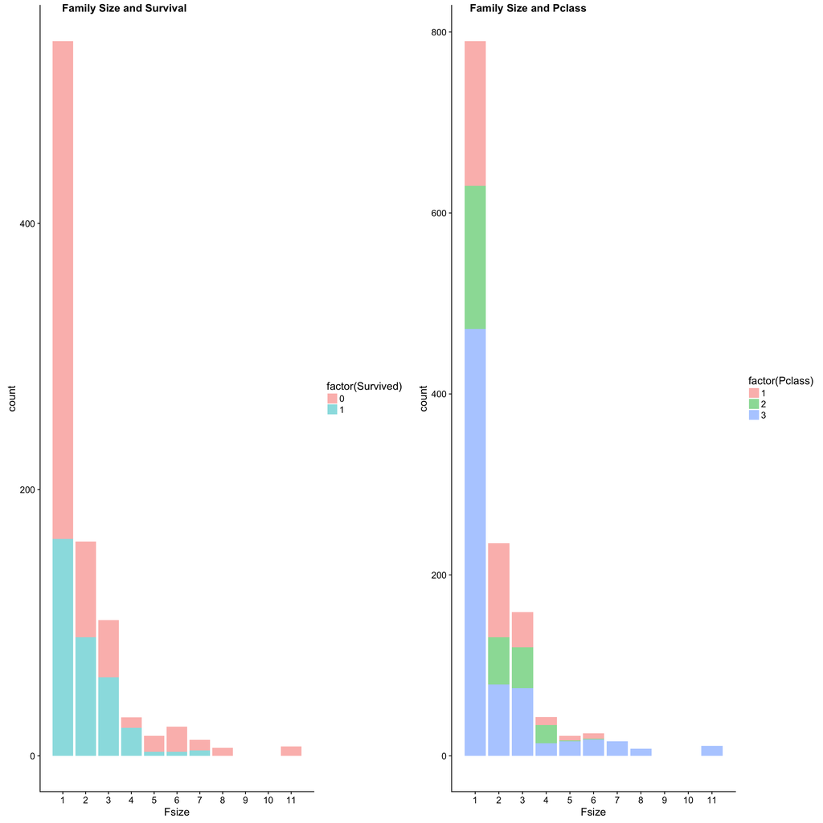

```r
# Histogram of Family size grouped using Survival status and Pclass
p_survival_hist<- ggplot(combined_data_new[!is.na(Survived)], aes(x = Fsize,fill=factor(Survived))) +
  geom_bar(alpha=0.5,stat = 'count')+
  scale_x_continuous(breaks=c(1:max(combined_data_new$Fsize)))

p_Pclass_hist<- ggplot(combined_data_new, aes(x = Fsize,fill=factor(Pclass))) +
  geom_bar(alpha=0.5,stat = 'count')+
  scale_x_continuous(breaks=c(1:max(combined_data_new$Fsize)))

plot_grid(p_survival_hist, p_Pclass_hist, nrow=1, labels=c('Family Size and Survival', 'Family Size and Pclass'))
```

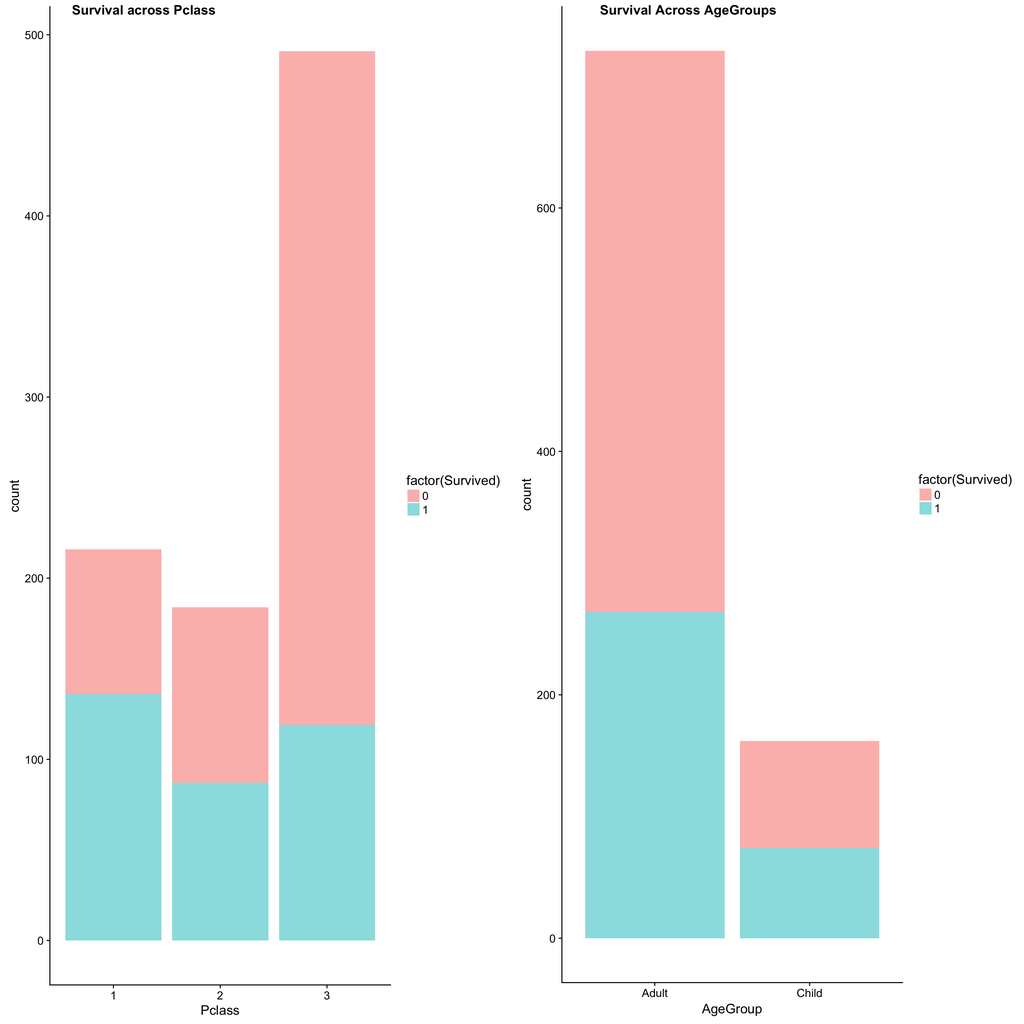

```r
# Histogram of Survival status grouped using Pclass and AgeGroup
p_survival_Pclass_hist<- ggplot(combined_data_new[!is.na(Survived)], aes(x = Pclass,
                                                fill=factor(Survived)))+
  geom_bar(alpha=0.5,stat = "count")

p_survival_Age_hist<-ggplot(combined_data_new[!is.na(Survived)], aes(x = AgeGroup,
                              fill=factor(Survived))) + geom_bar(alpha=0.5,stat = "count")


plot_grid(p_survival_Pclass_hist, p_survival_Age_hist, nrow=1, labels=c('Survival across Pclass', 'Survival Across AgeGroups'))
```

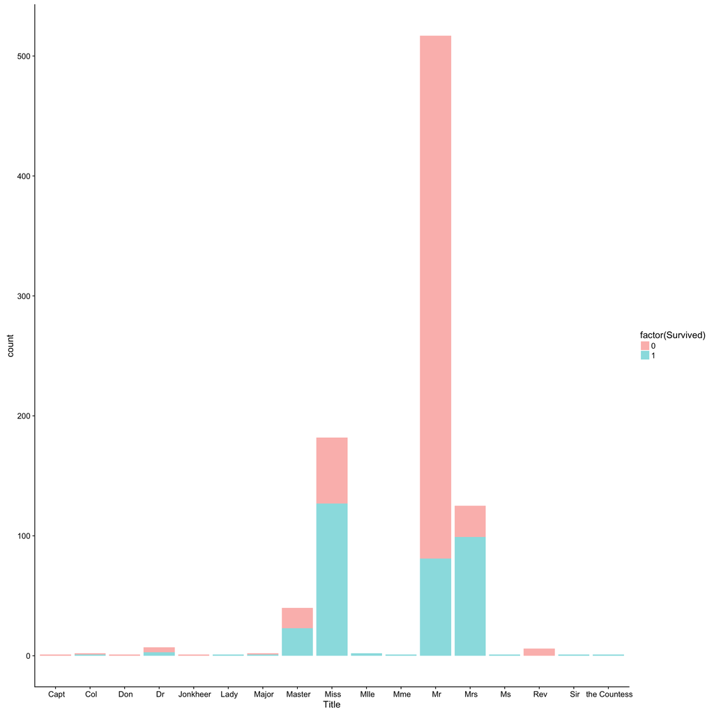

```r
combined_data$Title<- gsub("\\..*","",gsub(".*\\,","",combined_data$Name))
p_survival_Age_Title<-ggplot(combined_data[!is.na(Survived)], aes(x = Title,
                              fill=factor(Survived))) + geom_bar(alpha=0.5,stat = "count")

print(p_survival_Age_Title)
```

# 5 Machine learning

For the machine learning phase I used h2o R package to combine H2O models with XGBoost models into a Stacked Ensemble.

But before training the model i normalise variables Age, Fare and Fsize. Using a max-min normalisation method allowed me to boost my accuracy of the model on the test set.

```r
## create training data table

combined_data_new$Age <- (combined_data_new$Age - min(combined_data_new$Age))/(max(combined_data_new$Age)- min(combined_data_new$Age))

combined_data_new$Fsize <- (combined_data_new$Fsize - min(combined_data_new$Fsize))/(max(combined_data_new$Fsize)- min(combined_data_new$Fsize))

combined_data_new$Fare <- (combined_data_new$Fare - min(combined_data_new$Fare))/(max(combined_data_new$Fare)- min(combined_data_new$Fare))

df_train <- combined_data_new[!is.na(Survived)]

# set response variable as factor
df_train$Survived<- as.factor(df_train$Survived)

## use all other columns (except for the name) as predictors
predictors <- setdiff(names(df_train), c("Survived", "Name","PassengerId"))
```

## 5.1 Splitting the data in to test and train frames

Here i use 20% of the data points for testing and 80% for training

```r
splits <- h2o.splitFrame(
  data = as.h2o(df_train),
  ratios = c(0.8),   ## only need to specify 2 fractions, the 3rd is implied
  destination_frames = c("train.hex","test.hex"), seed = 1234
)
train <- splits[[1]]
test  <- splits[[2]]
```

## 5.2 Training H2O base models

```r
# Train & Cross-validate a (shallow) XGB-GBM
xgb1 <- h2o.xgboost(x = predictors,
                       y = "Survived",
                       training_frame = train,
                       distribution = "bernoulli",
                       ntrees = 10,
                       max_depth = 3,
                       min_rows = 2,
                       learn_rate = 0.2,
                       nfolds = 10,
                       fold_assignment = "Modulo",
                       keep_cross_validation_predictions = TRUE,
                       seed = 1)
# Train & Cross-validate another (deeper) XGB-GBM
xgb2 <- h2o.xgboost(x = predictors,
                       y = "Survived",
                       training_frame = train,
                       distribution = "bernoulli",
                       ntrees = 10,
                       max_depth = 8,
                       min_rows = 1,
                       learn_rate = 0.1,
                       sample_rate = 0.7,
                       col_sample_rate = 0.9,
                       nfolds = 10,
                       fold_assignment = "Modulo",
                       keep_cross_validation_predictions = TRUE,
                       seed = 1)
```

## 5.3 Train a stacked ensemble using the two xgBoost models

```r
ensemble <- h2o.stackedEnsemble(x = predictors,
                                y = "Survived",
                                training_frame = train,
                                model_id = "my_ensemble_binomial",
                                base_models = list(xgb1, xgb2))
```

## 5.4 Evaluate performance of the models

```r
# Eval ensemble performance on a test set
perf <- h2o.performance(ensemble, newdata = test)

# Compare to base learner performance on the test set
perf_xgb1_test <- h2o.performance(xgb1, newdata = test)
perf_xgb2_test <- h2o.performance(xgb2, newdata = test)


baselearner_best_auc_test <- max(h2o.auc(perf_xgb1_test), h2o.auc(perf_xgb2_test))
ensemble_auc_test <- h2o.auc(perf)
print(sprintf("Best Base-learner Test AUC:  %s", baselearner_best_auc_test))
```

```
## [1] "Best Base-learner Test AUC:  0.883307868601986"
```

```r
print(sprintf("Ensemble Test AUC:  %s", ensemble_auc_test))
```

```
## [1] "Ensemble Test AUC:  0.892857142857143"
```

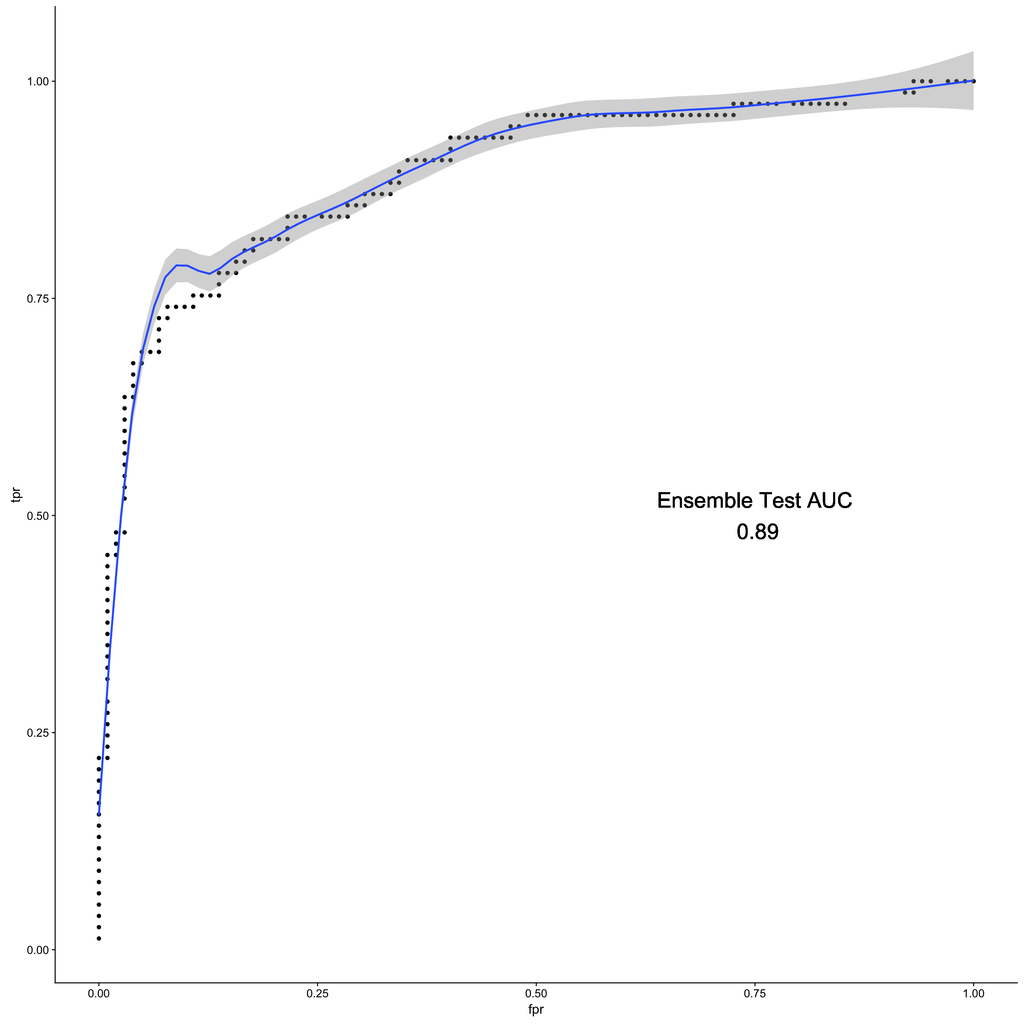

```r
# Eval ensemble performance on a test set
perf <- h2o.performance(ensemble, newdata = test)

perf_table<- data.table(perf@metrics$thresholds_and_metric_scores)
ggplot(perf_table,aes(x = fpr,y=tpr))+geom_point()+
  stat_smooth(method = "loess",span = 0.45)+
  geom_text(aes(x = 0.75, y = 0.5, label = paste("Ensemble Test AUC\n",round(ensemble_auc_test,2))),size = 8)
```

# 6 Time for predictions

```r
# Generate predictions on a test set
df_test <- combined_data_new[is.na(Survived)]
df_test$Survived<- as.factor(df_test$Survived)
pred <- as.data.table(h2o.predict(ensemble, newdata = as.h2o(df_test)))
pred$PredClass<- apply(pred,1,function(x) {which.max(x)})
pred$PredClass<- ifelse(pred$PredClass==1,1,0)
pred$PassengerId<- test_df$PassengerId
pred$Survived<- pred$PredClass

data_leader<- fread("submission_leaderboard.csv",sep=",")
dat<- merge(pred,data_leader,by="PassengerId")
cor(dat$Survived.x,dat$Survived.y)
```

```
## [1] 0.828294
```

```r
fwrite(pred[,c("PassengerId","Survived"),with=FALSE],"prediction_submission_04_ViM.csv",sep = ",")
```